# Lab 9

Baby Names

Author

Danial Shaikh

Make a summary table of the number of babies named “Allison” for each state and the sex of the baby. Specifically, the table should have the following qualities:

each state should be its own row

and each sex should have its own column

if there were no babies born for that combination of state & sex there should be a 0 (not an NA)

```r
# Load required packages
library(dplyr)
library(tidyr)
library(ggplot2)

data <- read.csv("StateNames_A.csv")

allison_data <- data %>%
  filter(Name == "Allison")

# Group by state and sex, calculate total count of babies named Allison
allison_summary <- allison_data %>%
  group_by(State, Gender) %>%
  summarize(Total = sum(Count))

allison_summary <- allison_summary %>%
  rename(`Sex at Birth` = Gender)

allison_summary <- allison_summary %>%
  replace_na(list(Total = 0))

allison_summary
```

```
# A tibble: 52 × 3
# Groups:   State [51]
   State `Sex at Birth` Total
   <chr> <chr>          <int>
 1 AK    F                232
 2 AL    F               1535
 3 AR    F               1198
 4 AZ    F               1880
 5 CA    F              12413
 6 CO    F               1594
 7 CT    F               1099
 8 DC    F                321
 9 DE    F                294
10 FL    F               4455
# … with 42 more rows
```

2. You should have seen in the table above that “Allison” is a name given overwhelmingly to babies assigned “female” at birth. So, create a new dataset named allison_f which contains only the babies assigned Female at birth.

```r
# Filter for babies assigned Female at birth
allison_f <- allison_data %>%
  filter(Gender == "F")
```

3. Make a visualization showing how the popularity of the name “Allison” has changed over the years. To be clear, each year should have one observation–the total number of Allisons born that year.

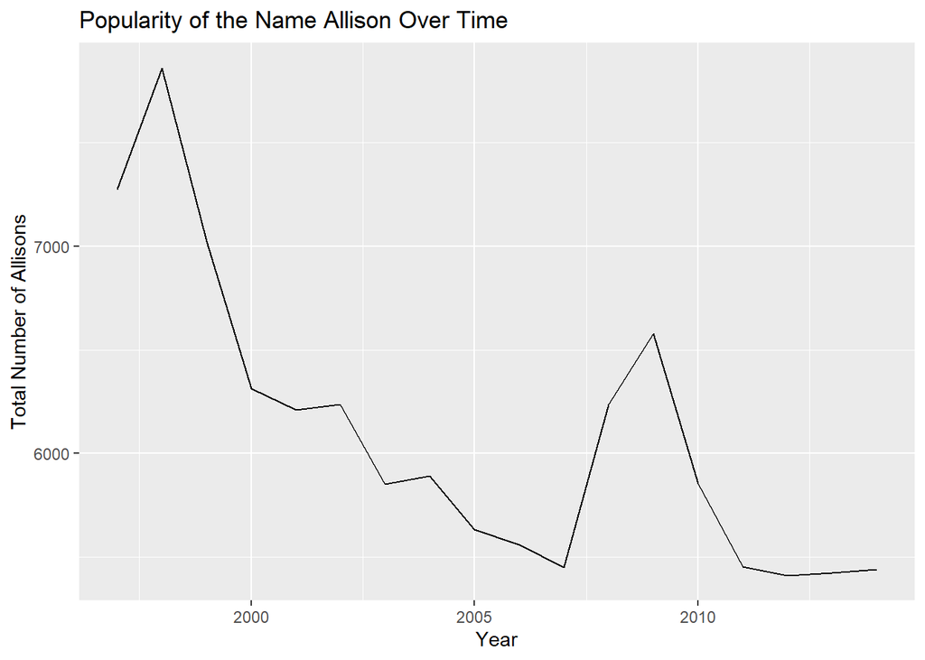

```r
# Group by year and calculate total count of babies named Allison
allison_yearly <- allison_data %>%
  group_by(Year) %>%
  summarize(Total = sum(Count))

# Create line chart
ggplot(allison_yearly, aes(x = Year, y = Total)) +
  geom_line() +
  labs(title = "Popularity of the Name Allison Over Time",
       x = "Year",
       y = "Total Number of Allisons")
```

## 1 **4 Modeling the Number of Allisons**

4. Fit a linear model with the year as the explanatory variable, and the number of Allisons as the response. Similar to #3, each year should have **one** observation–the total number of Allisons born that year.

```r
# Fit linear model
allison_lm <- lm(Total ~ Year, data = allison_yearly)

# View summary of linear model
summary(allison_lm)
```

```
Call:
lm(formula = Total ~ Year, data = allison_yearly)

Residuals:
    Min      1Q  Median      3Q     Max
-514.12 -352.39  -52.85  255.99 1004.81

Coefficients:
             Estimate Std. Error t value Pr(>|t|)
(Intercept) 209815.05   42883.25   4.893 0.000163 ***
Year          -101.58      21.38  -4.751 0.000217 ***
---
Signif. codes:  0 '***' 0.001 '**' 0.01 '*' 0.05 '.' 0.1 ' ' 1

Residual standard error: 470.7 on 16 degrees of freedom
Multiple R-squared:  0.5852,    Adjusted R-squared:  0.5592
F-statistic: 22.57 on 1 and 16 DF,  p-value: 0.0002172
```

```r
allison_lm
```

```
Call:
lm(formula = Total ~ Year, data = allison_yearly)

Coefficients:
(Intercept)         Year
   209815.1       -101.6
```

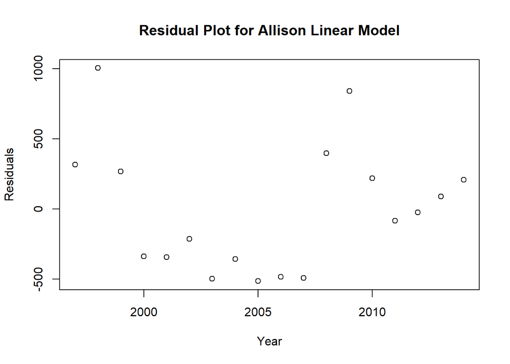

```r
# Create residual plot
plot(allison_yearly$Year, residuals(allison_lm),
     xlab = "Year", ylab = "Residuals",
     main = "Residual Plot for Allison Linear Model")
```

7. What do you conclude from this model? Is my name not cool anymore?

   5 Spelling by State

   In middle school I was so upset with my parents for not naming me “Allyson”. Past my pre-teen rebellion, I’m happy with my name and am impressed when baristas spell it “Allison” instead of “Alison”. But I don’t have it as bad as my good friend Allan!
   8. Narrow the A name dataset (downloaded previously) down to only male-assigned babies named “Allan”, “Alan”, or “Allen”. Make a plot comparing the popularity of these names over time.

```r
# Filter for Allan, Alan, or Allen for male babies
allan_alan_allen_m <- all_names %>%
  filter(Name %in% c("Allan", "Alan", "Allen"), Gender == "M")
```

[output not shown]

```r
ggplot(allan_alan_allen_m, aes(x = Year, y = Count, color = Name)) +
  geom_line() +
  labs(title = "Popularity of Allan, Alan, and Allen Over Time",
       x = "Year", y = "Count") +
  theme_bw()
```

[output not shown]

9.

- In California, Allan’s spelling of his name is the least common of the three but perhaps it’s not such an unusual name for his home state of Pennsylvania. Compute the total number of babies born with each spelling of “Allan” in the year 2000, in Pennsylvania and in California. Specifically, the table should have the following qualities:
  - each spelling should be its own column
  - each state should have its own row
  - a `0` (not an `NA`) should be used to represent locations where there were no instances of these names

```r
# Filter for Allan, Alan, or Allen for male babies in 2000 in Pennsylvania and California
allan_alan_allen_2000 <- all_names %>%
  filter(Name %in% c("Allan", "Alan", "Allen"), Gender == "M", Year == 2000, State %in% c("PA", "CA"))
```

[output not shown]

```r
allan_alan_allen_2000_summary <- allan_alan_allen_2000 %>%
  group_by(State, Name) %>%
  summarize(Total = sum(Count), .groups = "drop")
```

[output not shown]

```r
allan_alan_allen_2000_wide <- pivot_wider(allan_alan_allen_2000_summary, names_from = Name, values_from = Total, values_fill = 0)
```

[output not shown]

```r
# Print table
allan_alan_allen_2000_wide
```

[output not shown]

10. Convert your total counts to overall percents. That is, what was the percent breakdown between the three spellings in CA? What about in PA?

In California:

- Allan: 5.5%
- Alan: 27.8%
- Allen: 66.7%

In Pennsylvania:

- Allan: 5.2%
- Alan: 24.5%
- Allen: 70.4%

So in both California and Pennsylvania, the most common spelling of the name in the year 2000 was “Allen”, with “Alan” being the second most common and “Allan” the least common.